# 1141_社會資料分析 作業一

姓名：劉晏成

## 題目

以「2018台北大學社會系三鶯調查」（brilliant_working.sav）檔案回答下列問題：

1. 以「完全排除遺漏值」的設定，做教育程度（a8）、個人收入（b1）兩個變數的相關分析
2. 以「數列平均數」置換個人收入的遺漏值，並以此置換後的新變數做與教育程度的相關分析
3. 計算受訪者的環境行為（c1）總分
   - 運用「選擇觀察值」功能，分別報告男性和女性環境行為的平均數

# Q1: 教育程度（a8）、個人收入（b1）兩個變數的相關分析

## Review the data

**Review the variable labels of education and income**

```
Education
{1.0: '無', 2.0: '自修', 3.0: '小學肄業', 4.0: '國(初)中', 5.0: '初職', 6.0: '高中普通科', 7.0: '高中職業科', 8.0: '高職', 9.0: '士官學校', 10.0: '五專', 11.0: '二專', 12.0: '三專', 13.0: '軍警專修班', 14.0: '軍警專科班', 15.0: '空中行專', 16.0: '空中大學', 17.0: '軍警官學校', 18.0: '技術學院、科大', 19.0: '大學', 20.0: '碩士', 21.0: '博士', 22.0: '其他', 997.0: '拒答', 9…


Income
{0.0: '無收入', 1.0: '未滿1萬元', 2.0: '1萬元以上，未滿2萬元', 3.0: '2萬元以上，未滿3萬元', 4.0: '3萬元以上，未滿4萬元', 5.0: '4萬元以上，未滿5萬元', 6.0: '5萬元以上，未滿6萬元', 7.0: '6萬元以上，未滿7萬元', 8.0: '7萬元以上，未滿8萬元', 9.0: '8萬元以上，未滿9萬元', 10.0: '9萬元以上，未滿10萬元', 11.0: '10萬元以上，未滿11萬元', 12.0: '11萬元以上，未滿12萬元', 13.0: '12萬元以上，未滿13萬元', 14.0: '13萬元以上，未滿14萬元',…
```

**Review the distributions of education and income**

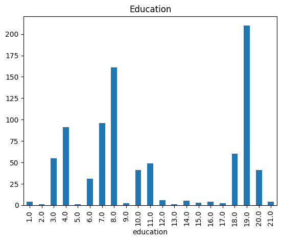

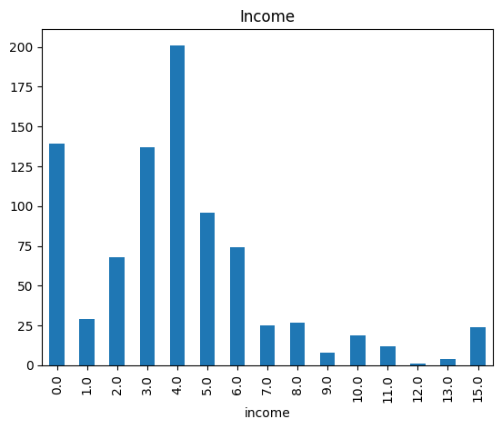

## Filter "無", "自修", "初職" out from education

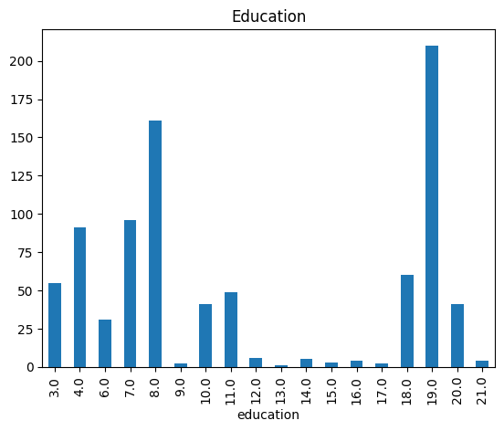

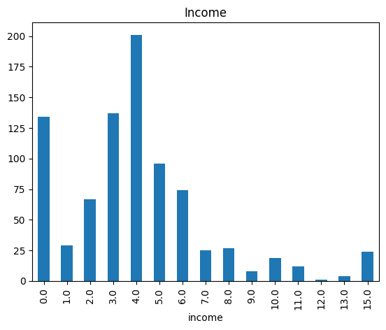

## Recode on education

Rules：

1. 小學
2. 國中
3. 高中職
4. 大學與專科
5. 研究所以上

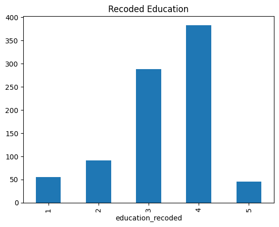

## Recode on income

Rules：

1. 無收入
2. 低收入（未滿2萬元）
3. 中低收入（2-4萬元）
4. 中等收入（4-6萬元）
5. 中高收入（6-8萬元）
6. 高收入（8萬元以上）

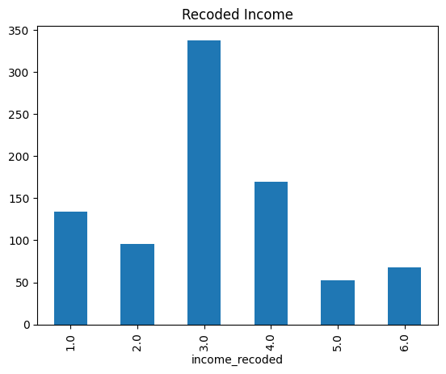

## Answers

### Q1-a: 完全排除遺漏值

**Perform Pearson Correlation**

|  | Metric | Value |
| --- | --- | --- |
| 0 | Pearson Correlation Coefficient | 0.3280 |
| 1 | P-value | 0.0000 |
| 2 | Sample Size | 858 |
| 3 | Significance Level (α=0.05) | Significant |
| 4 | Interpretation | Moderate Positive |

### Q1-b: 以「數列平均數」置換個人收入的遺漏值，並以此置換後的新變數做與教育程度的相關分析

**Perform Pearson Correlation**

|  | Metric | Value |
| --- | --- | --- |
| 0 | Pearson Correlation Coefficient | 0.3272 |
| 1 | P-value | 0.0000 |
| 2 | Sample Size | 862 |
| 3 | Significance Level (α=0.05) | Significant |
| 4 | Interpretation | Moderate Positive |

# Q2: 受訪者的環境行為（c1）與性別分析

## 環境行為（c1）總分

Add a new column(c1_sum) as the sum of columns c1a to c1g

|  | sex | c1_sum |
| --- | --- | --- |
| 0 | 2.0 | 20.0 |
| 1 | 1.0 | 19.0 |
| 2 | 2.0 | 17.0 |
| 3 | 1.0 | 20.0 |
| 4 | 2.0 | 20.0 |
| ... | ... | ... |
| 863 | 2.0 | 17.0 |
| 864 | 2.0 | 18.0 |
| 865 | 2.0 | 21.0 |
| 866 | 1.0 | 22.0 |
| 867 | 1.0 | 20.0 |

868 rows × 2 columns

## Answers

報告男性和女性環境行為的平均數

| sex | count | mean | std | min | 25% | 50% | 75% | max |
| --- | --- | --- | --- | --- | --- | --- | --- | --- |
| 男 | 418.0 | 17.416268 | 3.275360 | 7.0 | 15.0 | 17.0 | 19.0 | 28.0 |
| 女 | 450.0 | 19.288889 | 3.242413 | 10.0 | 17.0 | 19.0 | 21.0 | 28.0 |